# AI505/AI801, Optimization – Exercise Sheet 09

Published

April 22, 2026

Solutions Included.

Exercises with the symbol $^+$ are to be done at home before the class. Exercises with the symbol $^*$ will be tackled in class. The remaining exercises are left for self training after the exercise class. Some exercises are from the text book and the number is reported. They have the solution at the end of the book.

# 1 $^+$ (11.1)

Suppose you do not know any optimization algorithm for solving a linear program. You decide to evaluate all the vertices and determine, by inspection, which one minimizes the objective function. Give a loose upper bound on the number of possible minimizers you will examine. Furthermore, does this method properly handle all linear constrained optimization problems?

We have chosen to minimize a linear program by evaluating every vertex in the convex polytope formed by the constraints. Every vertex is thus a potential minimizer. Vertices are defined by intersections of active constraints. As every inequality constraint can either be active or inactive, and assuming there are $n$ inequality constraints, we do not need to examine more than $2^n$ combinations of constraints. This method does not correctly report unbounded linear constrained optimization problems as unbounded.

# 2 $^+$ (11.2)

If the program in Example 11.1 of [KW] is bounded below, argue that the simplex method must converge.

The simplex method is guaranteed either to improve with respect to the objective function with each step or to preserve the current value of the objective function. Any linear program will have a finite number of vertices. So long as a heuristic, such as Bland’s rule, is employed such that cycling does not occur, the simplex method must converge on a solution.

# 3 $^+$ (11.3)

Suppose we want to solve:
$$\begin{aligned}
\text{minimize}\:\:& 6x_1 +5x_2\\
\text{subject to}\:\: & 3x_1-2x_2 \geq 5.
\end{aligned}$$
How would we translate this problem into a linear program in equality form with the same minimizer?

The problem is already in minimization form. Let’s rewrite the inequality in less than equal form:
$$\begin{aligned}
\text{minimize}\:\:& 6x_1 +5x_2\\
\text{subject to}\:\: & -3x_1+2x_2 \leq -5.
\end{aligned}$$
Since both variables are free, to put the problem in a form in which all variables are greater or equal to 0 we introduce two new variables for each original one:

$$\begin{matrix}
x_1=s_1-s_2\\
s_1,s_2\geq 0
\end{matrix}
\qquad
\begin{matrix}
x_2=s_3-s_4\\
s_3,s_4\geq 0
\end{matrix}$$

which yields

$$\begin{aligned}
\text{minimize}\:\:& 6s_1-6s_2 +5s_3-5s_4\\
\text{subject to}\:\: & -3s_1+3s_2+2s_3-2s_4 \leq -5\\
&s_,s_2,s_3,s_4,s_5\geq 0
\end{aligned}$$

Finally, adding a slack variable $s_5\geq 0$:

$$\begin{aligned}
\text{minimize}\:\:& 6s_1-6s_2 +5s_3-5s_4\\
\text{subject to}\:\: & -3s_1+3s_2+2s_3-2s_4 + s_5 = -5\\
&s_,s_2,s_3,s_4,s_5\geq 0
\end{aligned}$$

The simplex algorithm works by selecting a basis and then changing the basis. The initial basis has to be feasible. This implies that the martix $A_B$ is invertible and that the solution $x_B=A_B^{-1}b\geq 0$. The basis in a problem of size $1\times 5$ has size $1$.

Let’s select $s_1$ to be in basis.

```python
import numpy as np

c = np.array([6, -6,5,-5,0])
A = np.array([[-3,3,2,-2,1]])
b = np.array([-5])

# initial basis
B = np.array([0])
N = np.array([1,2,3,4])

#%%
print("c_B:",c[B])
print("c_N:",c[N])
```

```
c_B: [6]
c_N: [-6  5 -5  0]
```

# 4

Consider the following problem:
$$\begin{aligned}
\text{minimize} \; &5x_1 + 4x_2\\
\text{ s.t.}\;& 2x_1 + 3x_2 \leq 5\\
&4x_1 + x_2 \leq 11\\
&x_1,x_2\geq 0
\end{aligned}$$
Solve the problem numerically implementing the simplex algorithm.

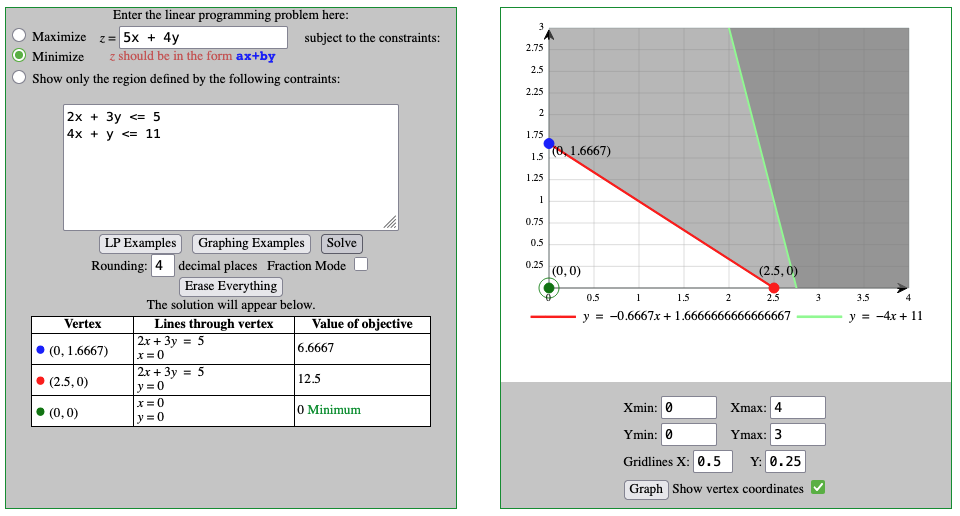

```python
import numpy as np

c = np.array([-5, -4, 0, 0])
A = np.array([[2, 3, 1, 0], [4, 1, 0, 1]])
b = np.array([5, 7])

# initial *feasible* basis
B = np.array([2,3])
N = np.array([0,1])

#%%
def compute_solution(A,b,B):
    A_B_inv = np.linalg.inv(A[:,B])
    x_B = A_B_inv @ b
    return x_B, A_B_inv

def compute_reduced_costs(A, A_B_inv, b,c,B,N) -> np.array:
    muN = c[N]-np.transpose(A_B_inv  @ A[:,N]) @ c[B]
    return muN

def choose_entering_var(muN, N):
    #q = np.argmin(muN)
    for i in range(N.shape[0]):
        if muN[i]<0:
            return N[i]

    raise SystemExit("Optimal")

def compute_leaving_var(A,A_B_inv, x_B,B,N,q):
    x_prime_q_s = np.zeros(A.shape[0])
    for i in range(B.shape[0]):
        # p=B[i]
        x_prime_q = x_B[i] / (A_B_inv @ A[:,q])[i]
        x_prime_q_s[i] = x_prime_q

    i = np.argmin(x_prime_q_s) # leaving var
    return (i, B[i], x_prime_q_s[i])

def run(A,b,c,B,N):
    niter = 1
    while True and niter<=5:
        print("Iteration",niter)
        x_B, A_B_inv = compute_solution(A,b,B)
        print("Base indices:",B)
        print("Basic solution:",x_B)
        muN = compute_reduced_costs(A,A_B_inv,b,c,B,N)
        print("Reduced costs",muN)
        if muN.min()>=0:
          print("Optimal")
          break
        q = choose_entering_var(muN, N)
        print("Entering:",q)
        i, p, x_B_p = compute_leaving_var(A,A_B_inv,x_B,B,N,q)
        print("Leaving",p)
        x_B[i] = x_B_p
        B[i] = q
        N[N==q] = p
        print(B,N, x_B)
        niter+=1

run(A,b,c,B,N)
```

```
Iteration 1
Base indices: [2 3]
Basic solution: [5. 7.]
Reduced costs [-5. -4.]
Entering: 0
Leaving 3
[2 0] [3 1] [5.   1.75]
Iteration 2
Base indices: [2 0]
Basic solution: [1.5  1.75]
Reduced costs [ 1.25 -2.75]
Entering: 1
Leaving 2
[1 0] [3 2] [0.6  1.75]
Iteration 3
Base indices: [1 0]
Basic solution: [0.6 1.6]
Reduced costs [0.7 1.1]
Optimal
```

```python
import numpy as np

c = np.array([6, -6,5,-5,0])
A = np.array([[-3,3,2,-2,1]])
b = np.array([-5])

# initial basis
B = np.array([0])
N = np.array([1,2,3,4])

run(A,b,c,B,N)
```

```
Iteration 1
Base indices: [0]
Basic solution: [1.66666667]
Reduced costs [ 0.  9. -9.  2.]
Entering: 3
Leaving 0
[3] [1 2 0 4] [2.5]
Iteration 2
Base indices: [3]
Basic solution: [2.5]
Reduced costs [-13.5   0.   13.5  -2.5]
Entering: 1
Leaving 3
[1] [3 2 0 4] [-1.66666667]
Iteration 3
Base indices: [1]
Basic solution: [-1.66666667]
Reduced costs [-9.  9.  0.  2.]
Entering: 3
Leaving 1
[3] [1 2 0 4] [2.5]
Iteration 4
Base indices: [3]
Basic solution: [2.5]
Reduced costs [-13.5   0.   13.5  -2.5]
Entering: 1
Leaving 3
[1] [3 2 0 4] [-1.66666667]
Iteration 5
Base indices: [1]
Basic solution: [-1.66666667]
Reduced costs [-9.  9.  0.  2.]
Entering: 3
Leaving 1
[3] [1 2 0 4] [2.5]
```

We observe that the optimal solution sometimes becomes negative and hence infeasible. This is not possible in the simplex algorithm. Once we have a feasible vertex we can always move to another feasible vertex. Hence, the implementation has a bug. Can you find it? Hint: the problem is in the function `compute_leaving_var`.

# 5 $^+$ (11.4)

Suppose your optimization algorithm has found a search direction $\vec d$ and you want to conduct a line search. However, you know that there is a linear constraint $\vec w^T {\vec x}\geq \vec 0$. How would you modify the line search to take this constraint into account? You can assume that your current design point is feasible.

If the current iterate ${\vec x}$ is feasible, then $\vec w^T{\vec x}= \vec b\geq \vec 0$. We want the next point to maintain feasibility, and thus we require $\vec w^T({\vec x}+\alpha\vec d)\geq \vec 0$. If the obtained value for $\alpha$ is positive, that $\alpha$ is an upper bound on the step length. If the obtained value for $\alpha$ is negative, it can be ignored

# 6 $^+$ (11.5)

Reformulate the linear program

$$\begin{aligned}
\text{minimize} \; &\vec c^T{\vec x}\\
\text{ s.t.}\;& A\vec x\geq 0
\end{aligned}$$
into an unconstrained optimization problem with a log barrier penalty.

$$\text{minimize} \; \vec c^T{\vec x}-\mu \sum_i\ln (A^T{i}{\vec x})$$

# 7

Reformulate the the problem of computing the analytic center of the set of linear inequalities

$$\vec a^T_i \vec x \leq \vec 1, i= 1,...,m, \quad |x_i| \leq 1, i= 1,...,n.$$

Note that we can choose $\vec x(0) = \vec 0$ as our initial point. You can generate instances of this problem by choosing $a_i$ from some distribution on $\mathbb{R}^n$ and then solving the problem with `scipy.optimize.minimize`.

# 8

Write the Lagrangian function for the following problem and derive the dual function $\cal D$. Determine $\vec x(\vec \lambda)$, the minimizer of $\cal D$ and the gradient of $\cal D$.

$$\begin{aligned}
\text{minimize} & (x_1 - 1)^2 + (x_2 - 1)^2\\
\text{subject to} &x_1 + 2x_2 - 1 = 0\\
&2x_1 + x_2 - 1 = 0
\end{aligned}$$

# 9 $^*$

A pharmaceutical company produces three types of drugs: A, B, and C. These drugs require raw materials, chemical processing time, and packaging units. The goal is to maximize profit, taking into account restrictions due to resource availability and production balance.

Formulate the problem in linear programming terms. Write first the *instantiated* model and then the abstract, *general* model separating model from data.

Data from the pharmaceutical company

| Drug | A | B | C |  |  |
| --- | --- | --- | --- | --- | --- |
| raw material (Kg) | 5 | 8 | 6 |  | 600 |
| processing time (hours) | 3 | 4 | 5 |  | 400 |
| packaging units | 2 | 3 | 1 |  | 200 |
| profit | 60 | 100 | 80 | -5 |  |

To model a problem in LP terms we need to define:

- the sets problem components and the known parameters
- the decision variables
- the objective function
- the constraints

Decision Variables

- $x_1$ Units of Drug A produced
- $x_2$ Units of Drug B produced
- $x_3$ Units of Drug C produced
- $x_4$ Additional packaging units (can be negative if surplus)

Objective Function (Maximization)
$$\text{maximize} \; Z=60x_1+100x_2+80x_3-5x_4$$

Constraints

Raw Material Constraint (Inequality) The factory has at most 600 kg of raw material:
$$5x_1+8x_2+6x_3\leq 600$$

Processing Time Constraint (Inequality) The available chemical processing time is 400 hours:
$$3x_1+4x_2+5x_3\leq 400$$

Packaging Balance Constraint (Equality) The total packaging units used must match available packaging plus extra units:
$$2x_1+3x_2+x_3=200+x_4$$

If $x_4>0$, extra packaging was bought.

If $x_4<0$, excess packaging is left unused.

Drug B Production Requirement (Equality) Due to contractual obligations, Drug B must be produced in exactly twice the amount of Drug A:
$$x_2=2x_1$$

Non-negativity and Unbounded Variables

$x_4$ can be negative (if packaging is left over) or positive (if additional units are purchased).

# 10 $^*$

Consider the following linear programming problem:
$$\begin{aligned}
\text{maximize} \;& Z=60x_1+100x_2+80x_3-5x_4\\
\text{ s.t.}\; &5x_1+8x_2+6x_3\leq 600\\
&3x_1+4x_2+5x_3\leq 400\\
&2x_1+3x_2+x_3=200+x_4\\
&x_2=2x_1\\
&x_1,x_2,x_3\geq 0\\
&x_4 \in \Re
\end{aligned}$$

Your tasks:

- Transform the problem in standard form
- Transform the problem in equality form
- Solve the problem numerically with `scipy.optimize.linprog`. Read this [tutorial](https://docs.scipy.org/doc/scipy/tutorial/optimize.html#linear-programming-linprog).

The standard or the equality forms are already good for `scipy.optimize.linprog`. However, let’s put the problem in yet another form that requires less manipulations from the initial given form.
$$\begin{aligned}
\text{minimize} \;& -Z=-60x_1-100x_2-80x_3+5x_4\\
\text{ s.t.}\; &5x_1+8x_2+6x_3+0x_4\leq 600\\
&3x_1+4x_2+5x_3+0x_4\leq 400\\
&2x_1+3x_2+x_3-x_4=200\\
&2x_1-x_2+0x_3+0x_4=0\\
&x_1,x_2,x_3\geq 0\\
&x_4 \in \Re
\end{aligned}$$

This corresponds to
$$c=\begin{bmatrix}
-60 & -100 & -80 & 5
\end{bmatrix}^T$$
$$\quad A_{ub}=
\begin{bmatrix}
5 & 8 & 6 & 0 \\
3 & 4 & 5 & 0
\end{bmatrix}
\quad b_{ub}=
\begin{bmatrix}
600 & 400
\end{bmatrix}^T$$
$$\quad A_{eq}=
\begin{bmatrix}
2 & 3 & 1 & -1 \\
2 & -1 & 0 & 0
\end{bmatrix}
\quad b_{eq}=
\begin{bmatrix}
200 & 0
\end{bmatrix}^T$$

```python
import numpy as np
from scipy.optimize import linprog
import array_to_latex as a2l

c = np.array([-60, -100, -80, 5])
A_ub = np.array([[5,8,6,0],
                [3,4,5,0]])
b_ub = np.array([600,400])

A_eq = np.array([[2,3,1,-1],
                [2,-1,0,0]])
b_eq = np.array([200, 0])

x1_bounds = (0, None)
x2_bounds = (0, None)
x3_bounds = (0, None)  # +/- np.inf can be used instead of None
x4_bounds = (-np.inf, +np.inf)

bounds = [x1_bounds, x2_bounds, x3_bounds, x4_bounds]

result = linprog(c, A_ub=A_ub, b_ub=b_ub, A_eq=A_eq, b_eq=b_eq, bounds=bounds,  options={"presolve": False})
print(result)

#%%
```

```
       message: Optimization terminated successfully. (HiGHS Status 7: Optimal)
        success: True
         status: 0
            fun: -7846.153846153847
              x: [ 1.538e+01  3.077e+01  4.615e+01 -3.077e+01]
            nit: 4
          lower:  residual: [ 1.538e+01  3.077e+01  4.615e+01        inf]
                 marginals: [ 0.000e+00  0.000e+00  0.000e+00  0.000e+00]
          upper:  residual: [       inf        inf        inf        inf]
                 marginals: [ 0.000e+00  0.000e+00  0.000e+00  0.000e+00]
          eqlin:  residual: [ 0.000e+00  0.000e+00]
                 marginals: [-5.000e+00  2.436e+00]
        ineqlin:  residual: [ 0.000e+00  0.000e+00]
                 marginals: [-7.051e+00 -6.538e+00]
 mip_node_count: 0
 mip_dual_bound: 0.0
        mip_gap: 0.0
```

Elements can be accesssed individually. For example the solution can be accessed by:

```python
print(result.x) # solution
print(result.fun) # objective function value
```

The residuals are the values of the slack variables and tell us whether the corresponding constraint is active or inactive in the optimal solution.

```python
print(result.x) # solution
print(result.fun) # objective function value
```

[output not shown]

# 11

Two opponents, say Antigonus and Brasidas, are fighting a battle over three mountain passes. Each of them commands seven legions. The one who sends more legions to a pass occupies it, but when the same number of legions meet, there will be a draw. Finally, the one who occupies more passes than the other wins the battle, with a draw occurring if both occupy the same number of passes.

They must simultaneously decide how to allocate their legions over the passes without knowing what the other will do. The goal is to win the most passes (or maximize some payoff based on the passes won). It makes sense to randomize the allocations to avoid being predictable. By randomized allocations, we mean that Antigonus is making his choices at random according to some probability distribution. Of course, the same applies to Brasidas. The problem is that they must decide on the probability distributions for their allocations. The probability distributions are defined over the set of all possible allocations of legions to the three passes.

(You can rethink the problem in the context of election or marketing competitions, if you like.)

Your tasks are:

1. Determine how many different allocations each opponent has.
2. Build the payoff matrix for Antigonus’ allocations on the rows and Brasidas’ allocations on the columns. Each element of the matrix gets 1 if Antigonus’allocation wins, -1 if Brasidas’ allocation wins and 0 otherwise.
3. Model the problem of finding the optimal strategy for Antigonus as a linear programming problem. Assume that Antigonous, when playing some randomized allocation, expects Brasidas to play a best response against this allocation. The goal of Antigonus is to maximize the worst-case expected payoff, say $v$. In this way, by adopting his optimal strategy, he can assure himself of winning $v$ on average.
4. Solve the linear programming problem with the tools from the Python module `scipy.optimize` and highlight the optimal strategy found for Antigonus and the optimal value, that is, the expected payoff (expected win for Antigonus).
5. Try changing the number of legions. Instead of seven, try with other numbers, say five, six, eight, nine. Do you find a case in which the optimal allocation strategy is deterministic, that is, a pure unique allocation?
6. Model the problem from the point of view of Brasidas, assuming that he also uses a randomized strategy. Use the same payoff matrix constructed for Antigonus. What is the expected payoff for him? Does the result make sense?